# Pedestrian Foot Traffic and Footpath Utilization (4) (2)

```python
from IPython.core.display import HTML

# Define the CSS styles
styles = """
<style>
.usecase-title, .usecase-authors {
    padding-left: 15px;
    padding-bottom: 10px;
    padding-top: 10px;
    padding-right: 15px;
    background-color: #0f9295;
    color: #fff;
}

.usecase-title {
    font-size: 1.7em;
    font-weight: bold;
}

.usecase-authors {
    background-color: #baeaeb;
    font-size: 1.4em;
    color: #121212;
}

.usecase-level-skill, .usecase-duration, .usecase-section-header, .usecase-subsection-header, .usecase-subsection-blurb {
    padding-left: 15px;
    padding-bottom: 7px;
    padding-top: 7px;
    background-color: #ffffff;
    font-size: 1.4em;
    color: #121212;
}

.usecase-level-skill {
    display: flex;
    justify-content: space-between;
}

.usecase-level, .usecase-skill {
    width: 50%;
    text-align: left;
}

.usecase-duration {
    text-align: left;
    padding-right: 15px;
    padding-bottom: 8px;
    font-size: 1.4em;
}

.usecase-section-header {
    font-weight: bold;
    font-size: 1.5em;
}

.usecase-subsection-header, .usecase-subsection-blurb {
    font-weight: bold;
    font-size: 1.2em;
    color: #121212;
}

.usecase-subsection-blurb {
    font-size: 1em;
    font-style: italic;
}
</style>
"""
```

```python
# Define the HTML content
content = """
<div class="usecase-title">Pedestrian Foot Traffic and Footpath Utilization New Use Case T2 2024</div>
<div class="usecase-authors"><b>Authored by: </b>Awaze Ur Rahaman Mohommed</div>
"""

# Display the styles and content
HTML(styles + content)
```

Pedestrian Foot Traffic and Footpath Utilization New Use Case T2 2024

**Authored by:** Awaze Ur Rahaman Mohommed

```python
content= """
<div class="usecase-duration"><b>Duration:</b> {90} mins</div>

<div class="usecase-level-skill">
    <div class="usecase-level"><b>Level: </b>{Intermediate}</div>
    <div class="usecase-skill"><b>Pre-requisite Skills: </b>Python & Basic Machine learning</div>
</div>
"""

# Display the styles and content
HTML(styles + content)
```

**Duration:** {90} mins

**Level:** {Intermediate}

**Pre-requisite Skills:** Python & Basic Machine learning

```python
content="""
<div class="usecase-section-header">Scenario</div>
"""

# Display the styles and content
HTML(styles + content)
```

Scenario

### Scenario for Pedestrian Analysis

#### For Council

- **Assessing Footpath Utilization and Pedestrian Safety**: Has the introduction of new footpaths and pedestrian infrastructure improved walkability and reduced pedestrian accidents?
- **Maintaining Footpath Quality**: How can the City of Melbourne maintain the quality of footpaths to ensure maximum usage and safety?
- **Predicting Footpath Wear and Tear**: Can we predict which footpaths will require maintenance soon to better allocate resources for repairs?
- **Decision on Footpath Expansion**: Based on congestion data, can the Council make informed decisions on which footpaths need expansion or substantial upgrades?

#### For Pedestrians

- **Justifying Infrastructure Investment**: Can the Council justify the spending on expensive pedestrian infrastructure improvements?
- **Informing Pedestrian Route Choices**: Can we predict which footpaths are most congested, so pedestrians can choose alternative, less crowded routes?

### Objective, Potential Benefits, and Background of the Use Case

#### Objectives for the Exploratory Data Analysis

Footpath utilization and pedestrian safety are critical components of a smart city. By analyzing pedestrian behavior and footpath conditions, we can improve the quality of life for residents and visitors. This use case aims to:

1. **Assess Footpath Utilization**: Determine if existing footpaths meet pedestrian needs or if additional footpaths are required in certain areas.
2. **Enhance Pedestrian Safety**: Analyze accident data to identify high-risk areas and implement measures to reduce pedestrian accidents.
3. **Predict Maintenance Needs**: Use data to predict footpath wear and tear, enabling proactive maintenance.
4. **Decision on Footpath Expansion**: Utilize congestion data to inform decisions on which footpaths need expansion or substantial upgrades.

### Background on Footpath Management in Victoria

The City of Melbourne aims to be a unique city driven by innovative solutions to accommodate changing needs, improve livability, and maintain leadership in sustainability. Maintaining a pool of datasets is critical to continuous improvement towards a smart city goal. This is achievable through innovative steps in pedestrian infrastructure management. Currently, footpaths are strategically located across key areas, but pedestrian congestion and wear and tear continue to cause high maintenance costs and safety concerns.

According to smart city principles, effective pedestrian infrastructure management is achievable with IoT and data analytics. Infrastructure (footpaths), IoT technology (sensors, GPS), and programming software for monitoring, scheduling, and overall system architecture are required. This intelligent system ensures real-time monitoring of footpath conditions, pedestrian traffic patterns, and potential maintenance needs.

### User Story

As a **City Planner**, I want to **analyze pedestrian walking patterns and footpath utilization**, so that I can **improve walkability, enhance pedestrian safety, optimize urban infrastructure**, and **make informed decisions on which footpaths need expansion or substantial upgrades** in Melbourne.

### Improvements and Additional Elements

```python
# import json
# import pathlib



# path = pathlib.Path().resolve()
# print(path)

# title = ''
# name = ''
# description = ''
# tags = []
# difficultly = ''
# technology = []
# datasets = []

# i = input("Enter the Title for you usecase: ")
# name = i
# title = name.replace(' ', '-').lower()

# d = input("\nEnter a short description for your use case (<100 characters): ")
# description = d[:100]

# diff = ['Beginner', 'Intermediate', 'Advanced']

# print("\nSelect 1, 2 or 3 from the following for level of difficulty")
# hard = input(f'1: {diff[0]}, 2: {diff[1]}, 3: {diff[2]}:\t')
# correct = False
# while correct ==False:
#     try:
#         choice = int(hard)
#         if choice in [1,2,3]:
#             correct = True
#         else:
#             hard = input(f'1: {diff[0]}, 2: {diff[1]}, 3: {diff[2]}:\t')
#     except:
#         hard = input(f'1: {diff[0]}, 2: {diff[1]}, 3: {diff[2]}:\t')

# difficultly = diff[choice-1]
# print(f'\n{difficultly}\n')


# print('\nEnter a tag (one at a time) such as "folium", "maps" or "safety" etc. Hit ENTER after each and ENTER when finished:')
# fin = False
# while fin == False:
#     t = input("tag: ")
#     if t =="":
#         fin = True
#     else:
#         tags.extend([t.lower()])
# print(tags)

# print('\nEnter a technology used (one at a time) such as "geojson", "seaborn", or "pandas" etc. Hit ENTER after each and ENTER when finished:')
# fin = False
# tech_hold = []
# while fin == False:
#     t = input("technology: ")
#     if t =="":
#         fin = True
#     else:
#         tech_hold.extend([t.lower()])
# print(tech_hold)

# technology.extend({"name":n,"code":"python"}for n in tech_hold)

# print('\nEnter the name for each CoM dataset used (one at a time) such as "pedestrian-traffic". Hit ENTER after each and ENTER when finished:')
# fin = False
# while fin == False:
#     ds = input("dataset: ")
#     if ds =="":
#         fin = True
#     else:
#         datasets.extend([ds.lower()])
# print(datasets)

# #Write to JSON, save in python file location
# meta = {'title':title, 'name':name, 'description':description, 'tags':tags, 'difficultly':difficultly, 'technology':technology, 'datasets':datasets}

# json_object = json.dumps(meta, indent = 4)
# with open(f"{path}/{title}.json", "w") as outfile:
#     outfile.write(json_object)
```

## Part 1 Pedestrian Counting System (counts per hour) Data Set Analysis

### Data extraction

```python
import pandas as pd
import numpy as np
import requests
from io import StringIO
import matplotlib.pyplot as plt
import seaborn as sns
import datetime
from shapely.geometry import Point
import geopandas as gpd
from statsmodels.tsa.arima.model import ARIMA
from sklearn.model_selection import train_test_split
from sklearn.metrics import mean_squared_error, r2_score
from sklearn.ensemble import GradientBoostingRegressor, RandomForestRegressor
from sklearn.neighbors import KNeighborsRegressor
from sklearn.compose import ColumnTransformer
from sklearn.preprocessing import OrdinalEncoder
import gmplot
```

In this section, we collect the pedestrian traffic data from the City of Melbourne's open datasets. This includes data on pedestrian counts at various sensors across the city.

```python
# function to collect data
def collect_data(dataset_id):
    base_url = 'https://data.melbourne.vic.gov.au/api/explore/v2.1/catalog/datasets/'
    dataset_id  = dataset_id
    format='csv'

    url = f'{base_url}{dataset_id}/exports/{format}'
    params = {
        'select': '*',
        'limit' : -1,
        'lang' : 'en',
        'timezone' : 'UTC'
    }

    response = requests.get(url,params=params)

    if response.status_code ==200:
        url_content = response.content.decode('utf-8')
        dataset = pd.read_csv(StringIO(url_content), delimiter=';')
        return dataset
    else:
        print(f"Request failed with status code: {response.status_code}")
```

Collecting pedestrian-counting-system-monthly-counts-per-hour dataset and footpaths datasets

```python
# pedestrian-counting-system-monthly-counts-per-hour dataset
dataset_id = 'pedestrian-counting-system-monthly-counts-per-hour'
dataset_id_footpath ='footpaths'
df = collect_data(dataset_id)
df_fpt = collect_data(dataset_id_footpath)
print(len(df))
df.head()
df_fpt.head()
```

```
1850393
```

|  | geo_point_2d | geo_shape | prop_id | name | shape_stle | addresspt1 | xorg | ext_id | asset_clas | label | ... | addresspt | asset_subt | xsource | profile | last_edi_1 | xdate | xdrawing | mcc_id | shape_star | roadseg_id |
| --- | --- | --- | --- | --- | --- | --- | --- | --- | --- | --- | --- | --- | --- | --- | --- | --- | --- | --- | --- | --- | --- |
| 0 | -37.811520853784295, 144.9726299624197 | {"coordinates": [[[[144.97246138210014, -37.81... | 0 | NaN | 67.416342 | 0.0 | RapidMap | RPSP0813103L1 | Road | NaN | ... | 0 | NaN | Photogrammetry | NaN | 2015-05-31T07:00:00+00:00 | 0 | NaN | 1390340 | 73.345962 | 0 |
| 1 | -37.80068337216389, 144.96077009093634 | {"coordinates": [[[[144.96078983650332, -37.80... | 0 | NaN | 53.826896 | 0.0 | RapidMap | RPSP03A11572 | Road | NaN | ... | 0 | NaN | Photogrammetry | NaN | 2015-05-31T07:00:00+00:00 | 0 | NaN | 1466123 | 15.544958 | 0 |
| 2 | -37.79923825289369, 144.95203494926486 | {"coordinates": [[[[144.95204944831843, -37.79... | 0 | NaN | 7.206967 | 0.0 | RapidMap | RPSP05B10594L1 | Road | NaN | ... | 0 | NaN | Photogrammetry | NaN | 2015-05-31T07:00:00+00:00 | 0 | NaN | 1386514 | 1.451706 | 0 |
| 3 | -37.78432064941155, 144.91812594664444 | {"coordinates": [[[[144.91890867546667, -37.78... | 0 | NaN | 433.368626 | 0.0 | RapidMap | RPSP07A10528L1 | Road | NaN | ... | 0 | NaN | Photogrammetry | NaN | 2015-05-31T07:00:00+00:00 | 0 | NaN | 1389155 | 489.999099 | 0 |
| 4 | -37.80199410738324, 144.97016734080813 | {"coordinates": [[[[144.97011191533144, -37.80... | 0 | NaN | 369.088767 | 0.0 | RapidMap | RPSP03A11495 | Road | NaN | ... | 0 | NaN | Photogrammetry | NaN | 2015-05-31T07:00:00+00:00 | 0 | NaN | 1466078 | 821.430735 | 0 |

5 rows × 27 columns

```python
df.head()
```

|  | id | location_id | sensing_date | hourday | direction_1 | direction_2 | pedestriancount | sensor_name | location |
| --- | --- | --- | --- | --- | --- | --- | --- | --- | --- |
| 0 | 421820211114 | 42 | 2021-11-14 | 18 | 25 | 24 | 49 | UM1_T | -37.80008566, 144.96386412 |
| 1 | 461320231124 | 46 | 2023-11-24 | 13 | 88 | 101 | 189 | Pel147_T | -37.80240719, 144.9615673 |
| 2 | 25420220305 | 25 | 2022-03-05 | 4 | 28 | 14 | 42 | MCEC_T | -37.82401776, 144.95604426 |
| 3 | 30320240804 | 30 | 2024-08-04 | 3 | 141 | 203 | 344 | Lon189_T | -37.8112185, 144.96656806 |
| 4 | 751120240108 | 75 | 2024-01-08 | 11 | 26 | 17 | 43 | SprFli_T | -37.81515276, 144.97467661 |

```python
df_fpt.drop(columns=['name','xorg','asset_clas','label','easting','asset_type', 'last_edite', 'created_us', 'northing', 'created_da', 'asset_subt', 'xsource', 'last_edi_1', 'xdate', 'xdrawing', 'mcc_id', 'shape_star', 'roadseg_id', 'prop_id', 'shape_stle','profile','addresspt1','addresspt'], inplace=True)
```

Identifying Missing Values and Summarizing Total Missing Values

```python
print(df.isna().sum())
print()
print("Dataset has",sum(df.isna().sum()),"missing values")
```

```
id                 0
location_id        0
sensing_date       0
hourday            0
direction_1        0
direction_2        0
pedestriancount    0
sensor_name        0
location           0
dtype: int64

Dataset has 0 missing values
```

```python
df_fpt=df_fpt.drop(columns=['str_id'])
```

```python
print(df_fpt.isna().sum())
print()
print("Dataset has",sum(df_fpt.isna().sum()),"missing values")
df_fpt=df_fpt.dropna()
print("Dataset has",sum(df_fpt.isna().sum()),"missing values")
```

```
geo_point_2d      0
geo_shape         0
ext_id          597
dtype: int64

Dataset has 597 missing values
Dataset has 0 missing values
```

```python
df.head()
```

|  | id | location_id | sensing_date | hourday | direction_1 | direction_2 | pedestriancount | sensor_name | location |
| --- | --- | --- | --- | --- | --- | --- | --- | --- | --- |
| 0 | 421820211114 | 42 | 2021-11-14 | 18 | 25 | 24 | 49 | UM1_T | -37.80008566, 144.96386412 |
| 1 | 461320231124 | 46 | 2023-11-24 | 13 | 88 | 101 | 189 | Pel147_T | -37.80240719, 144.9615673 |
| 2 | 25420220305 | 25 | 2022-03-05 | 4 | 28 | 14 | 42 | MCEC_T | -37.82401776, 144.95604426 |
| 3 | 30320240804 | 30 | 2024-08-04 | 3 | 141 | 203 | 344 | Lon189_T | -37.8112185, 144.96656806 |
| 4 | 751120240108 | 75 | 2024-01-08 | 11 | 26 | 17 | 43 | SprFli_T | -37.81515276, 144.97467661 |

Convert the date to date type

```python
#convert the date to date type
df.sensing_date=df.sensing_date.apply(pd.to_datetime)
print(df.sensing_date.dtypes)
```

```
datetime64[ns]
```

```python
df.head
print(df.sensing_date.dtypes)
```

```
datetime64[ns]
```

Drop the useless columns

```python
df.drop(columns=['direction_1','direction_2'],inplace=True)
```

## Filtering Sensors with Sufficient Data

```python
sensor_counts = df['sensor_name'].value_counts()
sensors_to_keep = sensor_counts[sensor_counts >= 5000].index.tolist()
df = df[df['sensor_name'].isin(sensors_to_keep)]
```

```python
df
```

|  | id | location_id | sensing_date | hourday | pedestriancount | sensor_name | location |
| --- | --- | --- | --- | --- | --- | --- | --- |
| 0 | 421820211114 | 42 | 2021-11-14 | 18 | 49 | UM1_T | -37.80008566, 144.96386412 |
| 1 | 461320231124 | 46 | 2023-11-24 | 13 | 189 | Pel147_T | -37.80240719, 144.9615673 |
| 2 | 25420220305 | 25 | 2022-03-05 | 4 | 42 | MCEC_T | -37.82401776, 144.95604426 |
| 3 | 30320240804 | 30 | 2024-08-04 | 3 | 344 | Lon189_T | -37.8112185, 144.96656806 |
| 4 | 751120240108 | 75 | 2024-01-08 | 11 | 43 | SprFli_T | -37.81515276, 144.97467661 |
| ... | ... | ... | ... | ... | ... | ... | ... |
| 1850388 | 631320230527 | 63 | 2023-05-27 | 13 | 1052 | Bou231_T | -37.81333081, 144.96675571 |
| 1850389 | 501620240323 | 50 | 2024-03-23 | 16 | 557 | Lyg309_T | -37.79808192, 144.96721013 |
| 1850390 | 201620240417 | 20 | 2024-04-17 | 16 | 478 | LtB170_T | -37.81172914, 144.9682466 |
| 1850391 | 621520230905 | 62 | 2023-09-05 | 15 | 382 | Lat224_T | -37.80996494, 144.96216521 |
| 1850392 | 39720211017 | 39 | 2021-10-17 | 7 | 12 | AlfPl_T | -37.81379749, 144.96995745 |

1832310 rows × 7 columns

Remove Outliers

```python
def remove_outliers(sensor):
    q1 = sensor['pedestriancount'].quantile(0.25)
    q3 = sensor['pedestriancount'].quantile(0.75)
    iqr = q3 - q1
    upper_bound = q3 + 2 * iqr
    return sensor[(sensor['pedestriancount'] <= upper_bound)]

df = df.groupby('sensor_name').apply(remove_outliers).reset_index(drop=True)
```

```python
print(df.shape)
df.head()
```

```
(1811488, 7)
```

|  | id | location_id | sensing_date | hourday | pedestriancount | sensor_name | location |
| --- | --- | --- | --- | --- | --- | --- | --- |
| 0 | 1081120231017 | 108 | 2023-10-17 | 11 | 639 | 261Will_T | -37.81295822, 144.95678789 |
| 1 | 108020230807 | 108 | 2023-08-07 | 0 | 68 | 261Will_T | -37.81295822, 144.95678789 |
| 2 | 1081020231021 | 108 | 2023-10-21 | 10 | 238 | 261Will_T | -37.81295822, 144.95678789 |
| 3 | 1081420231029 | 108 | 2023-10-29 | 14 | 380 | 261Will_T | -37.81295822, 144.95678789 |
| 4 | 1081920240314 | 108 | 2024-03-14 | 19 | 488 | 261Will_T | -37.81295822, 144.95678789 |

```python
# Ensure the Geo Point columns are formatted correctly
df_fpt['geo_point_2d'] = df_fpt['geo_point_2d'].apply(lambda x: tuple(map(float, x.split(','))))
df['geo_point_2d'] = df['location'].apply(lambda x: tuple(map(float, x.split(','))))

# Display the first few rows to confirm the formatting
df_fpt[['geo_point_2d']].head(), df[['geo_point_2d']].head()
```

```
(                               geo_point_2d
 0  (-37.811520853784295, 144.9726299624197)
 1  (-37.80068337216389, 144.96077009093634)
 2  (-37.79923825289369, 144.95203494926486)
 3  (-37.78432064941155, 144.91812594664444)
 4  (-37.80199410738324, 144.97016734080813),
                    geo_point_2d
 0  (-37.81295822, 144.95678789)
 1  (-37.81295822, 144.95678789)
 2  (-37.81295822, 144.95678789)
 3  (-37.81295822, 144.95678789)
 4  (-37.81295822, 144.95678789))
```

# Data Preprocessing

```python
from shapely.geometry import Point
import geopandas as gpd

# Convert pedestrian traffic data to GeoDataFrame
df['geometry'] = df['geo_point_2d'].apply(Point)
df_gdf = gpd.GeoDataFrame(df, geometry='geometry', crs="EPSG:4326")

# Convert footpaths data to GeoDataFrame
df_fpt['geometry'] = df_fpt['geo_point_2d'].apply(Point)
footpaths_gdf = gpd.GeoDataFrame(df_fpt, geometry='geometry', crs="EPSG:4326")

# Perform spatial join with a small distance tolerance
joined_gdf = gpd.sjoin_nearest(df_gdf, footpaths_gdf, how="left", distance_col="distance", max_distance=0.0001)

# Filter out rows where the distance is greater than the threshold

df_merged = joined_gdf[joined_gdf['distance'] <= 0.0001]

df_merged.head()
```

|  | id | location_id | sensing_date | hourday | pedestriancount | sensor_name | location | geo_point_2d_left | geometry | index_right | geo_point_2d_right | geo_shape | ext_id | distance |
| --- | --- | --- | --- | --- | --- | --- | --- | --- | --- | --- | --- | --- | --- | --- |
| 54368 | 86920220121 | 86 | 2022-01-21 | 9 | 71 | 574Qub_T | -37.80309992, 144.94908064 | (-37.80309992, 144.94908064) | POINT (-37.8031 144.94908) | 8468.0 | (-37.80310627220279, 144.94900473099938) | {"coordinates": [[[[144.9488839026519, -37.803... | RPSP05B11446L1 | 0.000076 |
| 54369 | 862320220827 | 86 | 2022-08-27 | 23 | 20 | 574Qub_T | -37.80309992, 144.94908064 | (-37.80309992, 144.94908064) | POINT (-37.8031 144.94908) | 8468.0 | (-37.80310627220279, 144.94900473099938) | {"coordinates": [[[[144.9488839026519, -37.803... | RPSP05B11446L1 | 0.000076 |
| 54370 | 86620231126 | 86 | 2023-11-26 | 6 | 5 | 574Qub_T | -37.80309992, 144.94908064 | (-37.80309992, 144.94908064) | POINT (-37.8031 144.94908) | 8468.0 | (-37.80310627220279, 144.94900473099938) | {"coordinates": [[[[144.9488839026519, -37.803... | RPSP05B11446L1 | 0.000076 |
| 54371 | 861320220826 | 86 | 2022-08-26 | 13 | 132 | 574Qub_T | -37.80309992, 144.94908064 | (-37.80309992, 144.94908064) | POINT (-37.8031 144.94908) | 8468.0 | (-37.80310627220279, 144.94900473099938) | {"coordinates": [[[[144.9488839026519, -37.803... | RPSP05B11446L1 | 0.000076 |
| 54372 | 86820240423 | 86 | 2024-04-23 | 8 | 82 | 574Qub_T | -37.80309992, 144.94908064 | (-37.80309992, 144.94908064) | POINT (-37.8031 144.94908) | 8468.0 | (-37.80310627220279, 144.94900473099938) | {"coordinates": [[[[144.9488839026519, -37.803... | RPSP05B11446L1 | 0.000076 |

```python
joined_gdf.head()
print(df_merged.shape)
```

```
(566508, 14)
```

Looking for any missing values

```python
print(df_merged.isna().sum())
print()
print("Dataset has",sum(df_merged.isna().sum()),"missing values")
```

```
id                    0
location_id           0
sensing_date          0
hourday               0
pedestriancount       0
sensor_name           0
location              0
geo_point_2d_left     0
geometry              0
index_right           0
geo_point_2d_right    0
geo_shape             0
ext_id                0
distance              0
dtype: int64

Dataset has 0 missing values
```

```python
df_merged.drop(columns=['geo_point_2d_left','geometry','index_right','distance'],inplace=True)
```

```python
df_merged.head()
```

|  | id | location_id | sensing_date | hourday | pedestriancount | sensor_name | location | geo_point_2d_right | geo_shape | ext_id |
| --- | --- | --- | --- | --- | --- | --- | --- | --- | --- | --- |
| 54368 | 86920220121 | 86 | 2022-01-21 | 9 | 71 | 574Qub_T | -37.80309992, 144.94908064 | (-37.80310627220279, 144.94900473099938) | {"coordinates": [[[[144.9488839026519, -37.803... | RPSP05B11446L1 |
| 54369 | 862320220827 | 86 | 2022-08-27 | 23 | 20 | 574Qub_T | -37.80309992, 144.94908064 | (-37.80310627220279, 144.94900473099938) | {"coordinates": [[[[144.9488839026519, -37.803... | RPSP05B11446L1 |
| 54370 | 86620231126 | 86 | 2023-11-26 | 6 | 5 | 574Qub_T | -37.80309992, 144.94908064 | (-37.80310627220279, 144.94900473099938) | {"coordinates": [[[[144.9488839026519, -37.803... | RPSP05B11446L1 |
| 54371 | 861320220826 | 86 | 2022-08-26 | 13 | 132 | 574Qub_T | -37.80309992, 144.94908064 | (-37.80310627220279, 144.94900473099938) | {"coordinates": [[[[144.9488839026519, -37.803... | RPSP05B11446L1 |
| 54372 | 86820240423 | 86 | 2024-04-23 | 8 | 82 | 574Qub_T | -37.80309992, 144.94908064 | (-37.80310627220279, 144.94900473099938) | {"coordinates": [[[[144.9488839026519, -37.803... | RPSP05B11446L1 |

Converting hourday to h:m:s format

```python
df['hour'] = pd.to_timedelta(df['hourday'], unit='h').apply(lambda x: str(x).split(' ')[-1])
```

```python
df.head()
```

|  | id | location_id | sensing_date | hourday | pedestriancount | sensor_name | location | geo_point_2d | geometry | hour |
| --- | --- | --- | --- | --- | --- | --- | --- | --- | --- | --- |
| 0 | 1081120231017 | 108 | 2023-10-17 | 11 | 639 | 261Will_T | -37.81295822, 144.95678789 | (-37.81295822, 144.95678789) | POINT (-37.81295822 144.95678789) | 11:00:00 |
| 1 | 108020230807 | 108 | 2023-08-07 | 0 | 68 | 261Will_T | -37.81295822, 144.95678789 | (-37.81295822, 144.95678789) | POINT (-37.81295822 144.95678789) | 00:00:00 |
| 2 | 1081020231021 | 108 | 2023-10-21 | 10 | 238 | 261Will_T | -37.81295822, 144.95678789 | (-37.81295822, 144.95678789) | POINT (-37.81295822 144.95678789) | 10:00:00 |
| 3 | 1081420231029 | 108 | 2023-10-29 | 14 | 380 | 261Will_T | -37.81295822, 144.95678789 | (-37.81295822, 144.95678789) | POINT (-37.81295822 144.95678789) | 14:00:00 |
| 4 | 1081920240314 | 108 | 2024-03-14 | 19 | 488 | 261Will_T | -37.81295822, 144.95678789 | (-37.81295822, 144.95678789) | POINT (-37.81295822 144.95678789) | 19:00:00 |

Splitting the latitude and longitude for analysis

```python
df[['latitude', 'longitude']] = df['location'].str.split(', ', expand=True)

df['latitude'] = pd.to_numeric(df['latitude'])
df['longitude'] = pd.to_numeric(df['longitude'])
```

```python
print(df_merged['sensor_name'].unique())
```

```
['574Qub_T' 'AG_T' 'AlfPl_T' 'BouHbr2353_T' 'Eli380_T' 'Eli501_T'
 'Errol20_T' 'FLDegC_T' 'FLDegN_T' 'FLDegS_T' 'FliSS_T' 'FliS_T'
 'Fra118_T' 'KenMac_T' 'King2_T' 'Lon189_T' 'LtB210_T' 'NewQ_T' 'PriNW_T'
 'Que85_T' 'SanBri_T' 'Signal1647_T' 'SouthB_T' 'Spr201_T' 'Swa295_T']
```

# Data Visualization

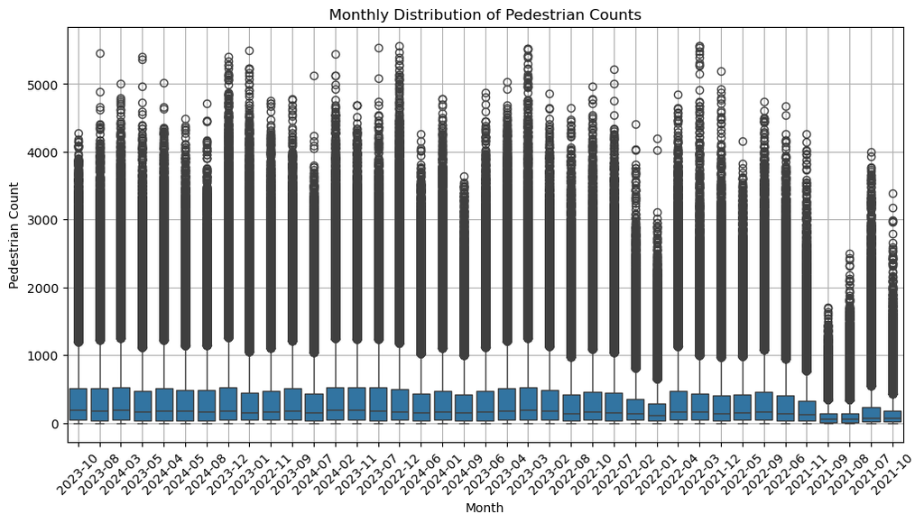

```python
df['month'] = df['sensing_date'].dt.to_period('M')

plt.figure(figsize=(12, 6))
sns.boxplot(x=df['month'].astype(str), y='pedestriancount', data=df)
plt.xticks(rotation=45)
plt.title('Monthly Distribution of Pedestrian Counts')
plt.xlabel('Month')
plt.ylabel('Pedestrian Count')
plt.grid(True)
plt.show()
```

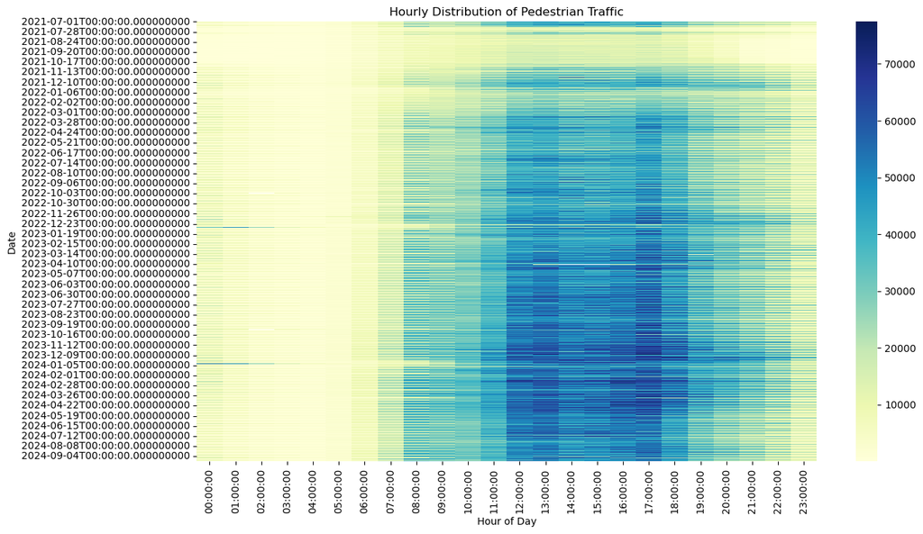

```python
pivot_table = df.pivot_table(values='pedestriancount', index='sensing_date', columns='hour', aggfunc='sum')

plt.figure(figsize=(14, 8))
sns.heatmap(pivot_table, cmap='YlGnBu', annot=False)
plt.title('Hourly Distribution of Pedestrian Traffic')
plt.xlabel('Hour of Day')
plt.ylabel('Date')
plt.show()
```

```python
import gmplot
import pandas as pd

# Replace with your own Google API key
google_api_key = 'AIzaSyAEXd7MhckinQiegbCGsCY6nDhh9XRxcso'

# Convert latitude and longitude to numeric if they aren't already
df['latitude'] = pd.to_numeric(df['latitude'])
df['longitude'] = pd.to_numeric(df['longitude'])

# Filter out high traffic locations (e.g., where pedestrian count > threshold)
threshold = df['pedestriancount'].quantile(0.9)  # Top 10% as hotspots
hotspots = df[df['pedestriancount'] > threshold]

# Initialize gmplot
gmap = gmplot.GoogleMapPlotter(hotspots['latitude'].mean(), hotspots['longitude'].mean(), 13, apikey=google_api_key)

# Mark the hotspots on the map
gmap.heatmap(hotspots['latitude'], hotspots['longitude'])

# Optionally, you can add markers for specific high-traffic points
for lat, lon, count in zip(hotspots['latitude'], hotspots['longitude'], hotspots['pedestriancount']):
    gmap.marker(lat, lon, title=f'Pedestrian Count: {count}')

# Save the map to an HTML file
gmap.draw("pedestrian_hotspots.html")

print("Map has been generated and saved as 'pedestrian_hotspots.html'")
```

```
Map has been generated and saved as 'pedestrian_hotspots.html'
```

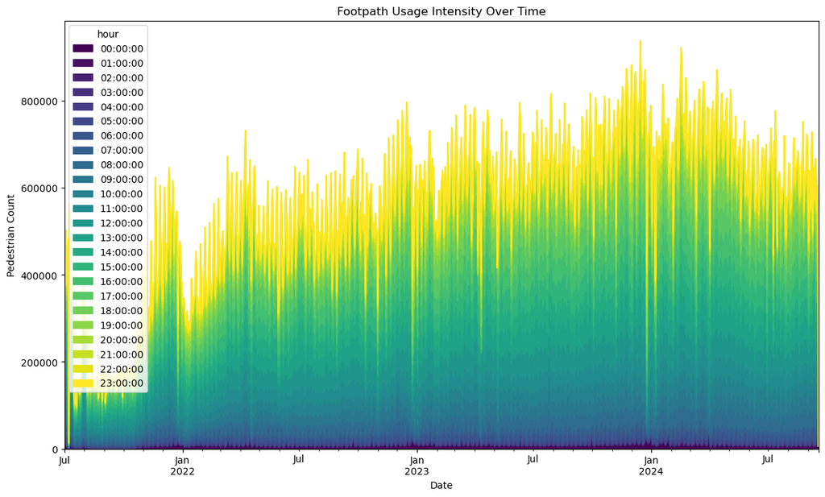

```python
pivot_table_area = df.pivot_table(values='pedestriancount', index='sensing_date', columns='hour', aggfunc='sum')

pivot_table_area.plot(kind='area', stacked=True, figsize=(14, 8), colormap='viridis')
plt.title('Footpath Usage Intensity Over Time')
plt.xlabel('Date')
plt.ylabel('Pedestrian Count')
plt.show()
```

```python
import pandas as pd
from sklearn.model_selection import train_test_split
from sklearn.linear_model import LinearRegression
from sklearn.metrics import mean_squared_error, r2_score

# Ensure the date is in datetime format
df['sensing_date'] = pd.to_datetime(df['sensing_date'])

# Feature engineering: Extract useful time features
df['day_of_week'] = df['sensing_date'].dt.dayofweek  # Day of the week
df['month'] = df['sensing_date'].dt.month  # Month of the year
df['year'] = df['sensing_date'].dt.year  # Year

# Select features and target variable
features = ['hourday', 'day_of_week', 'month', 'year']
target = 'pedestriancount'

X = df[features]
y = df[target]

# Split the data into training and testing sets
X_train, X_test, y_train, y_test = train_test_split(X, y, test_size=0.2, random_state=42)
```

```
ARIMA Model Mean Squared Error: 12414612266.48748
```

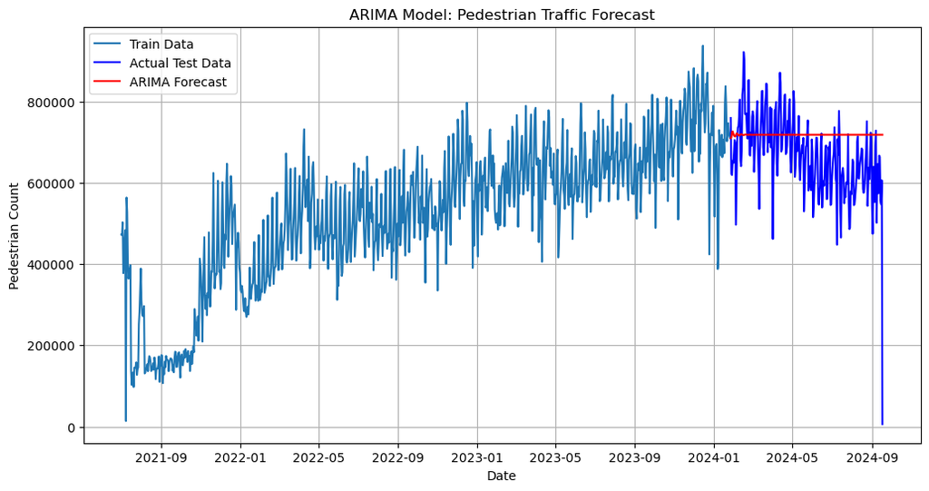

```python
import pandas as pd
from statsmodels.tsa.arima.model import ARIMA
from sklearn.metrics import mean_squared_error
import matplotlib.pyplot as plt

# Step 1: Prepare the data for time series forecasting
# Assuming df has 'sensing_date' (as datetime) and 'pedestriancount'

# Group by 'sensing_date' to get daily pedestrian counts
df_daily = df.groupby('sensing_date')['pedestriancount'].sum().reset_index()

# Set 'sensing_date' as the index for time series analysis
df_daily.set_index('sensing_date', inplace=True)

# Step 2: Split the data into training and testing sets
train_size = int(len(df_daily) * 0.8)  # 80% for training
train, test = df_daily[:train_size], df_daily[train_size:]

# Step 3: Fit the ARIMA model
# You can tune the (p, d, q) parameters as needed. Here, we use (5, 1, 0) for demonstration.
model = ARIMA(train, order=(5, 1, 0))
arima_model = model.fit()

# Step 4: Forecast pedestrian counts for the test set
forecast = arima_model.forecast(steps=len(test))

# Step 5: Evaluate the model using Mean Squared Error
mse_arima = mean_squared_error(test, forecast)
print(f"ARIMA Model Mean Squared Error: {mse_arima}")

# Step 6: Plot the actual vs forecasted pedestrian counts
plt.figure(figsize=(12, 6))
plt.plot(train.index, train['pedestriancount'], label='Train Data')
plt.plot(test.index, test['pedestriancount'], label='Actual Test Data', color='blue')
plt.plot(test.index, forecast, label='ARIMA Forecast', color='red')
plt.title('ARIMA Model: Pedestrian Traffic Forecast')
plt.xlabel('Date')
plt.ylabel('Pedestrian Count')
plt.legend()
plt.grid(True)
plt.show()
```

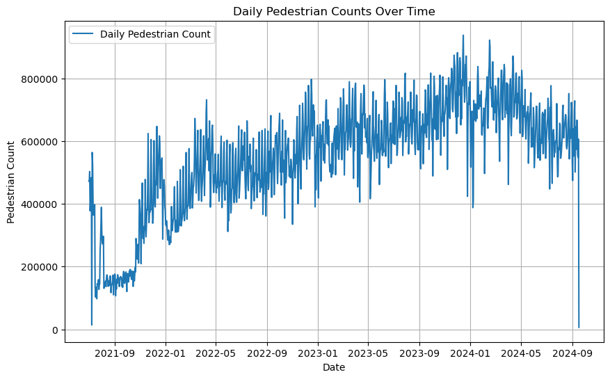

```
ARIMA Model Mean Squared Error: 12943340645.318718
```

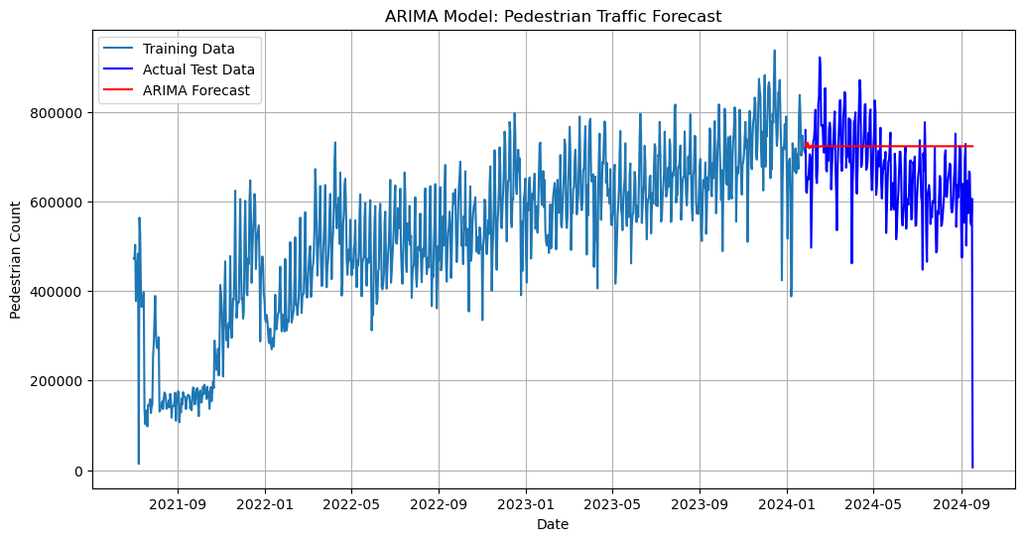

```python
import pandas as pd
from statsmodels.tsa.arima.model import ARIMA
from sklearn.metrics import mean_squared_error
import matplotlib.pyplot as plt

# Step 1: Data Preparation for Time Series
# Assuming df has 'sensing_date' (as datetime) and 'pedestriancount'

# Ensure 'sensing_date' is a datetime type
df['sensing_date'] = pd.to_datetime(df['sensing_date'])

# Group the data by sensing date to get daily pedestrian counts
df_daily = df.groupby('sensing_date')['pedestriancount'].sum().reset_index()

# Set 'sensing_date' as the index
df_daily.set_index('sensing_date', inplace=True)

# Step 2: Visualize the pedestrian counts
plt.figure(figsize=(10,6))
plt.plot(df_daily, label='Daily Pedestrian Count')
plt.title('Daily Pedestrian Counts Over Time')
plt.xlabel('Date')
plt.ylabel('Pedestrian Count')
plt.legend()
plt.grid(True)
plt.show()

# Step 3: Split the data into training and testing sets
train_size = int(len(df_daily) * 0.8)  # 80% for training
train, test = df_daily[:train_size], df_daily[train_size:]

# Step 4: Fit the ARIMA model
# (p, d, q) parameters can be adjusted depending on your data analysis (5, 1, 0) is an example
model = ARIMA(train, order=(6, 1, 1))  # p=5, d=1, q=0 are initial guesses, can be tuned
arima_model = model.fit()

# Step 5: Forecast pedestrian counts for the test set duration
forecast = arima_model.forecast(steps=len(test))

# Step 6: Evaluate the model using Mean Squared Error
mse_arima = mean_squared_error(test, forecast)
print(f"ARIMA Model Mean Squared Error: {mse_arima}")

# Step 7: Plot the actual vs forecasted pedestrian counts
plt.figure(figsize=(12, 6))
plt.plot(train.index, train['pedestriancount'], label='Training Data')
plt.plot(test.index, test['pedestriancount'], label='Actual Test Data', color='blue')
plt.plot(test.index, forecast, label='ARIMA Forecast', color='red')
plt.title('ARIMA Model: Pedestrian Traffic Forecast')
plt.xlabel('Date')
plt.ylabel('Pedestrian Count')
plt.legend()
plt.grid(True)
plt.show()
```

## Conclusion: Pedestrian Traffic Forecasting Using ARIMA

### Summary of the Analysis

In this use case, we leveraged **ARIMA** (AutoRegressive Integrated Moving Average) to forecast pedestrian traffic counts in the City of Melbourne. The steps involved in this analysis included:

1. **Data Collection**: We gathered pedestrian count data from various sensors across the city.
2. **Data Preprocessing**: Missing values were handled, and outliers were removed to ensure data quality. Time features were extracted for use in time series forecasting.
3. **Visualization**: Pedestrian traffic patterns were visualized through boxplots and heatmaps to identify trends in footpath usage over different times and dates.
4. **Forecasting with ARIMA**: Using ARIMA, we forecasted pedestrian traffic based on historical data, which allows the city planners to predict future footpath usage.

### Insights and Recommendations

1. **Footpath Expansion and Maintenance**: Based on the traffic forecasting, areas with consistently high pedestrian volumes can be prioritized for footpath expansion and timely maintenance.
2. **Congestion Prediction**: By predicting future pedestrian traffic, the city can better manage pedestrian congestion during peak times, such as weekends or holidays.
3. **Resource Allocation**: Forecasting pedestrian counts allows the city to allocate resources more efficiently. For example, sensors and footpaths that experience heavier foot traffic might require additional maintenance or improvements.